# NY Squirrels

Caroline Carrozzini

1/31/2023

```r
library(tidyverse)
nyc_squirrels <- readr::read_csv("https://raw.githubusercontent.com/rfordatascience/tidytuesday/master/data/2019/2019-10-29/nyc_squirrels.csv")
#install.packages("tidymodels")
library(tidymodels)
nyc_squirrels_splits <- initial_split(nyc_squirrels, prop = 0.5)
exploratory_data <- training(nyc_squirrels_splits)
test_data <- testing(nyc_squirrels_splits)
```

# Exploratory Data Questions

- What is the distribution of squirrel color?
- Where are the squirrels found?
- What is the distribution of squirrel color based on age?
- What is the distribution of squirrel color based on location?
- In what locations are the squirrels eating?
- What is the distribution of perceived height in trees based on age?

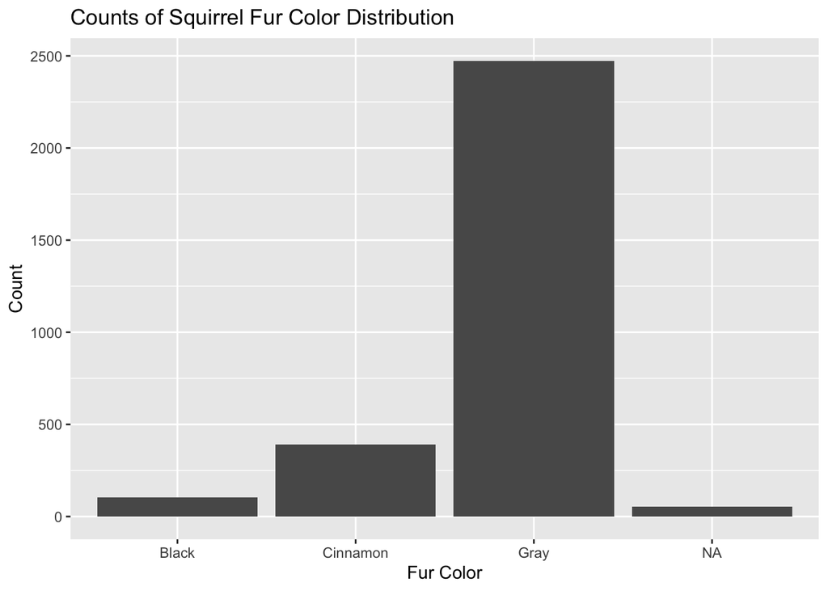

```r
nyc_squirrels %>%
  ggplot() +
  geom_bar(mapping = aes(x = primary_fur_color)) +
  labs(title = "Counts of Squirrel Fur Color Distribution",
       x = "Fur Color", y = "Count")
```

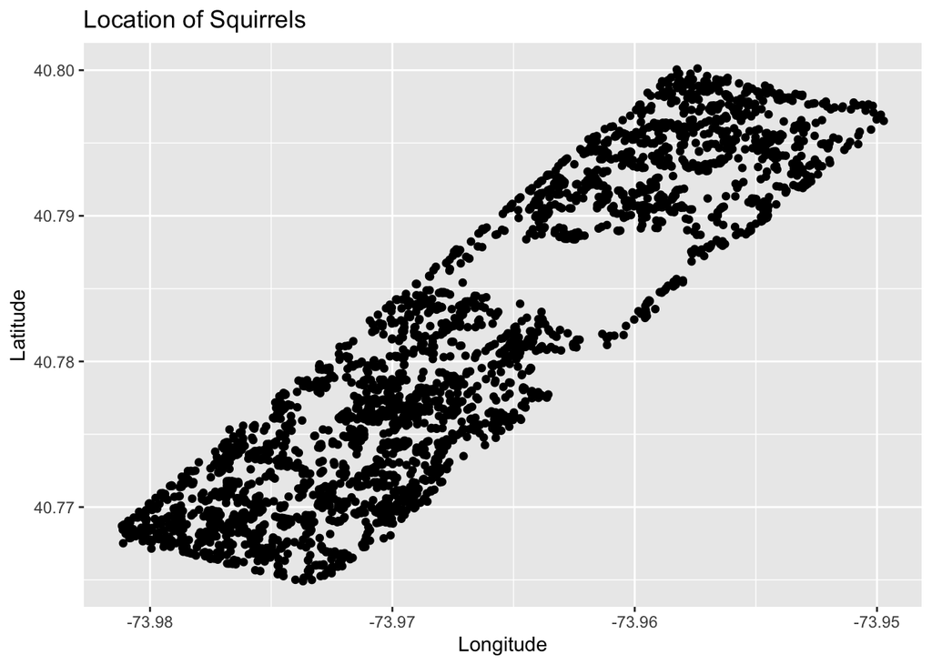

```r
nyc_squirrels %>%
  ggplot() +
  geom_point(mapping = aes(x = long, y = lat)) +
  labs(title = "Location of Squirrels",
       x = "Longitude",
       y = "Latitude")
```

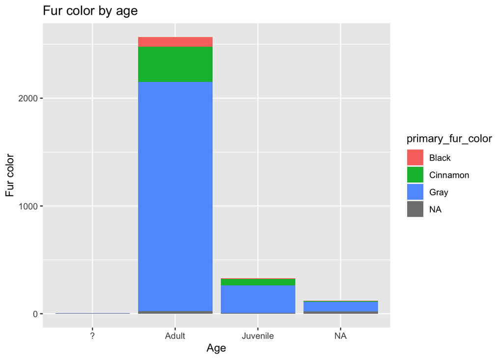

```r
nyc_squirrels %>%
  ggplot() +
  geom_bar(mapping = aes(x = age, fill = primary_fur_color)) +
  labs(title = "Fur color by age",
       x = "Age",
       y = "Fur color")
```

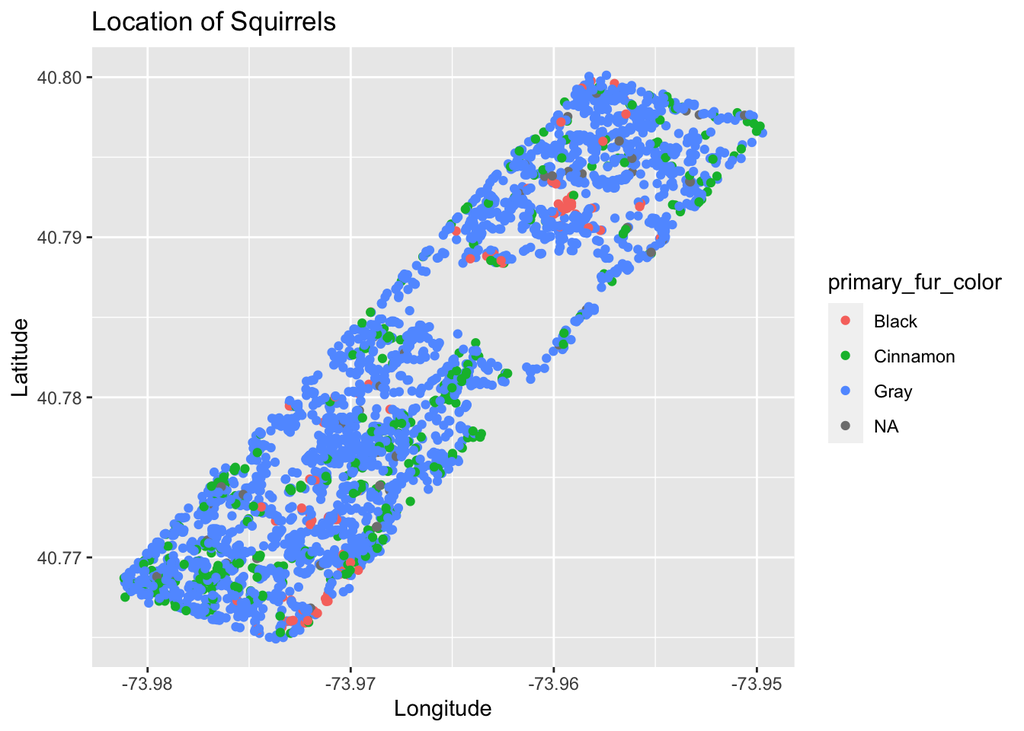

```r
nyc_squirrels %>%
  ggplot() +
  geom_point(mapping = aes(x = long, y = lat, color = primary_fur_color)) +
  labs(title = "Location of Squirrels",
       x = "Longitude",
       y = "Latitude")
```

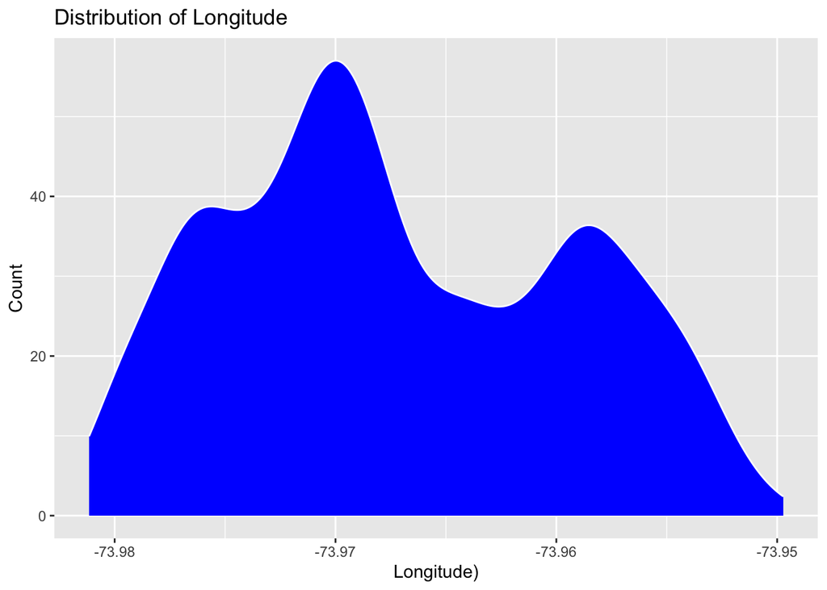

```r
nyc_squirrels %>%
  ggplot() +
  geom_density(mapping = aes(x = long),
                 color = "white",
                 fill = "blue") +
  labs(title ="Distribution of Longitude",
       x = "Longitude)", y = "Count")
```

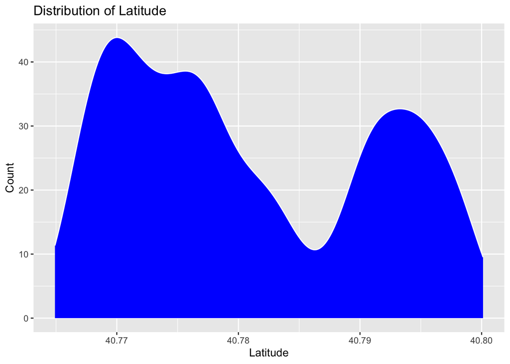

```r
nyc_squirrels %>%
  ggplot() +
  geom_density(mapping = aes(x = lat),
                 color = "white",
                 fill = "blue") +
  labs(title ="Distribution of Latitude",
       x = "Latitude", y = "Count")
```

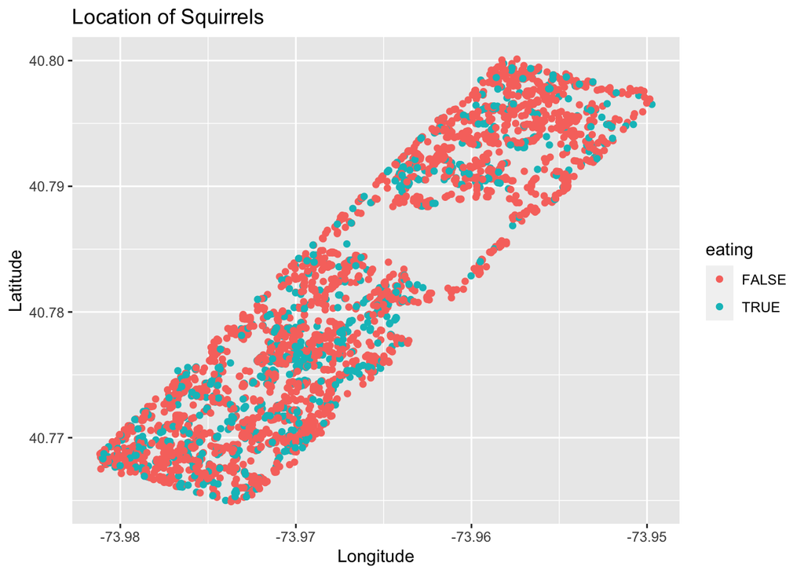

```r
nyc_squirrels %>%
  ggplot() +
  geom_point(mapping = aes(x = long, y = lat, color = eating)) +
  labs(title = "Location of Squirrels",
       x = "Longitude",
       y = "Latitude")
```

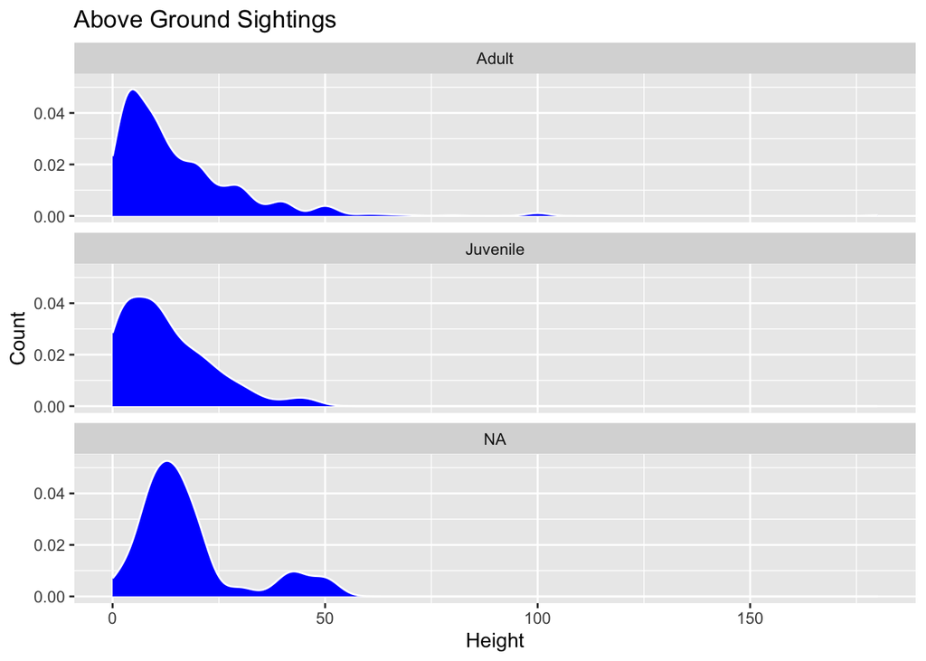

```r
nyc_squirrels %>%
  filter(above_ground_sighter_measurement != FALSE) %>%
  mutate(above_ground_sighter_measurement= as.numeric(above_ground_sighter_measurement)) %>%
  mutate(age= ifelse(age=="?", NA, age)) %>%
  ggplot() +
  geom_density(mapping = aes(x = above_ground_sighter_measurement, fill= age),
                 color = "white",
                 fill = "blue") +
  labs(title ="Above Ground Sightings",
       x = "Height", y = "Count") +
  facet_wrap(~age, ncol = 1)
```

# Hypotheses

- 1. Do squirrels’ fur colors change with age?
- 2. Do squirrels’ climbing potential change with age?

# Methodology

In this section, I will be using “new” data that was not seen in the exploratory analyses prior to this. I will be using simulation methods in an attempt to answer the hypotheses that were previously stated. Using this type of method will allow for more accurate results since there are different factors that play into the intervals and not everything has an equal opportunity of happening.

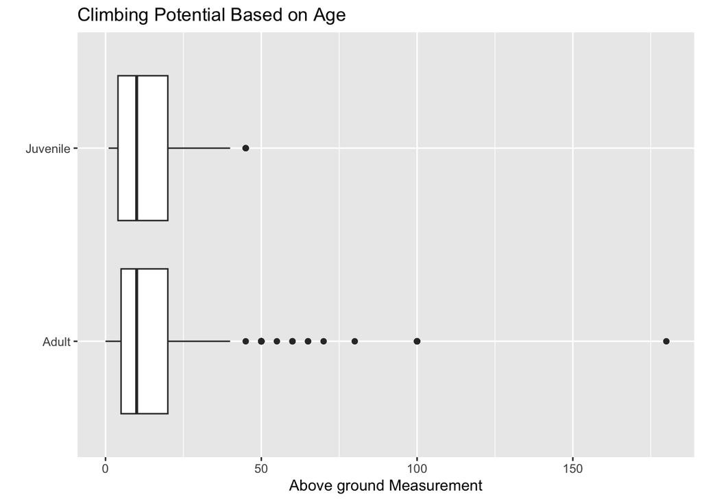

```r
nyc_squirrels %>%
  filter(age!="NA") %>%
  filter(age != "?") %>%
  filter(above_ground_sighter_measurement != FALSE) %>%
  mutate(above_ground_sighter_measurement= as.numeric(above_ground_sighter_measurement)) %>%
  mutate(age= ifelse(age=="?", NA, age)) %>%
  ggplot() +
  geom_boxplot(mapping = aes(x = above_ground_sighter_measurement, y = age)) +
  labs(title = "Climbing Potential Based on Age",
       x = "Above ground Measurement",
       y = "")
```

Here, we are looking at the distribution of location in trees height wise based on squirrel ages.

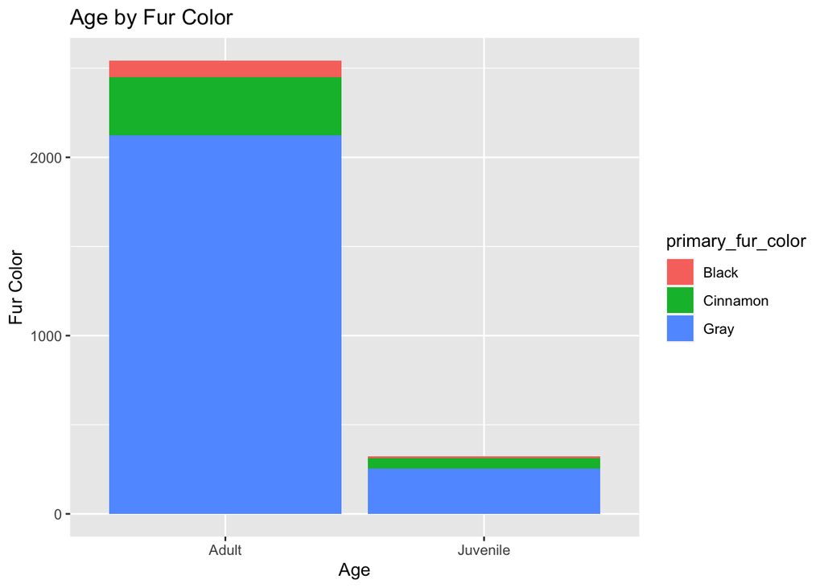

```r
nyc_squirrels %>%
  filter(age!="NA") %>%
  filter(age != "?") %>%
  mutate(age= ifelse(age=="?", NA, age)) %>%
   filter(primary_fur_color!="NA") %>%
  ggplot() +
  geom_bar(mapping = aes(x = age, fill = primary_fur_color)) +
  labs(title = "Age by Fur Color",
       x = "Age",
       y = "Fur Color")
```

In this barplot, we are looking at the distribution of fur color based on age.